# Étude de la production de pommes

Représentez graphiquement (Boxplot) la productivité globale des facteurs pour les producteurs prenant conseil ou non.

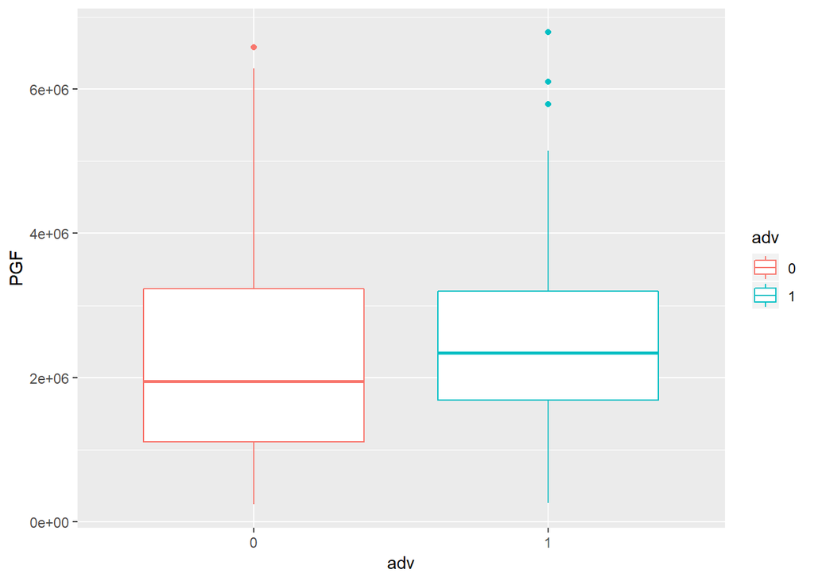

```
##
##                     0  1
##   gros_producteur  15 20
##   petit_producteur 52 53
```

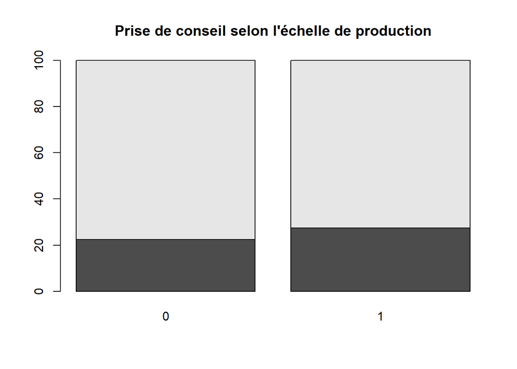

**Quelles sont les entreprises les plus performantes aux vues statistiques descriptives.**

=> cf feuille

# Estimation des fonctions de production linéaire

## Linéaire

$$q_i = \alpha + \sum_{k=1}^{3} \beta_k x_ik + \epsilon_i$$

Avec une fonction de production linéaire on suppose implicitement que les facteurs de production sont des substituts.

```
===============================================
                        Dependent variable:
                    ---------------------------
                               qOut
-----------------------------------------------
qLab                         11.831***
                              (1.272)

qMat                         46.668***
                             (11.234)

qCap                           1.788
                              (1.995)

Constant                 -1,615,979.000***
                           (231,771.700)

-----------------------------------------------
Observations                    140
R2                             0.787
Adjusted R2                    0.782
Residual Std. Error  1,540,737.000 (df = 136)
F Statistic          167.318*** (df = 3; 136)
===============================================
Note:               *p<0.1; **p<0.05; ***p<0.01
```

Obtenez-vous une fonction de production monotone croissante ?

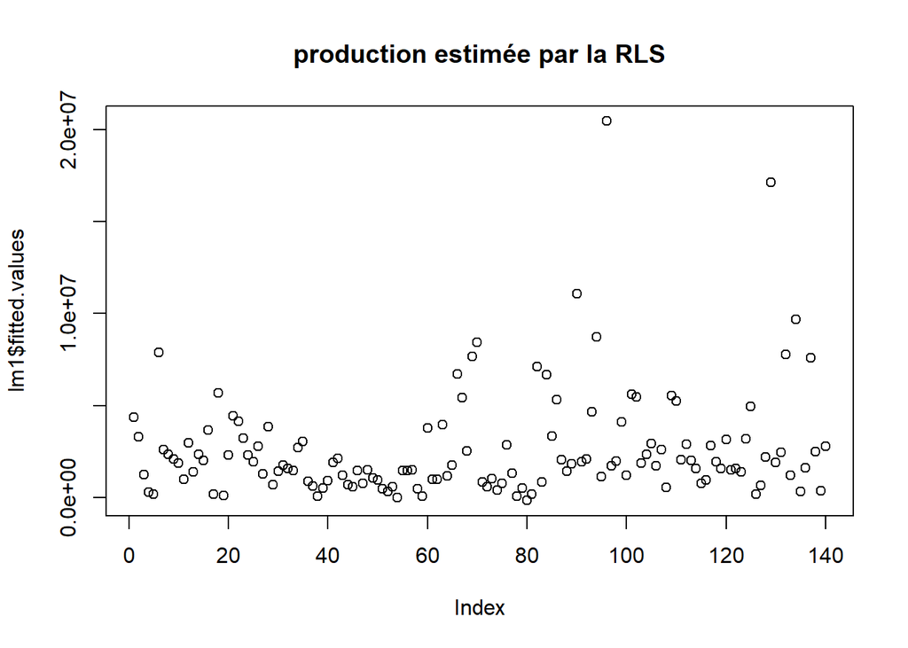

** Le coefficient associé au facteur de production du capital est il significatif ? **

La quantité de capitale n’est pas significative. Les autres quantités sont significatives au seuil de 1%.

**Peut-on dire que chaque facteur de production est essentiel ?**

Oui chaque facteur est essentiel à la production ce n’est pas parce que le coefficient du capital n’est pas significatif que l’on doit en déduire cela. Il faut surtout estimer une autre fonction de production.

**Comparer à l’aide d’un graphique la production observée et la production estimée**

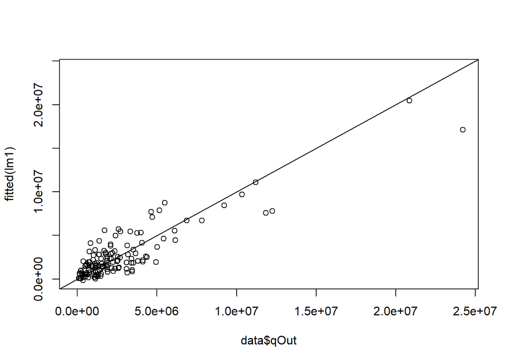

```
[1] 1
```

```
  (Intercept)          qLab          qMat          qCap
-1.615979e+06  1.183114e+01  4.666811e+01  1.788279e+00
```

**Vérifier si la production est toujours positive**

```
[1] 1
```

```
        80         54         78         59         38
-150393.80   20171.41   78296.69   82313.04   84998.85
```

Il y a une production estimée qui est négative